# Worksheet 5

Gabriel Singer

18.12.2023/30.01.2024

## DOM from Berlin´s surface waters

Data source: Romero Gonzalez-Quijano 2022. Biogeosciences 19: 2841-2853, https://doi.org/10.5194/bg-19-2841-2022 A range of urban water bodies in Berlin´s extensive ‘aquascape’ were investigated for properties of dissolved organic matter (DOM). There were 4 seasonal campaigns, water bodies were classified into 2 lotic (rivers and streams) and 2 lentic (lakes and ponds) types. DOM can be considered to drive and indicate various ecosystem functions like respiration, primary production. It may also indicate pollution and react to input from the terrestrial surrounding.

We will need the ‘vegan’ package (a lot of ordinations coded by ecologists for ecologists). Some more classical ordinations like PCA are available in the package ‘MASS’.

```r
library(vegan)
```

```r
library(MASS)
library(shape) # just for better arrows drawing

DOM<-read.table(file="data/DOM_Berlin_Romero.txt",header=TRUE)
names(DOM)
```

```
##  [1] "sampleID"   "Season"     "Site"       "Date"       "Type"
##  [6] "latitude"   "longitude"  "SR"         "E2_E3"      "E4_E6"
## [11] "SUVA254"    "FI"         "HIX"        "fresh"      "DOC"
## [16] "C1"         "C2"         "C3"         "C4"         "C5"
## [21] "C6"         "C7"         "HMWS.C"     "humic.C"    "LMWS.C"
## [26] "HMWS.N"     "humic.N"    "avgmolmass" "molrich"    "DBE"
## [31] "AI"         "MLB"        "H_C"        "O_C"        "NH4"
## [36] "NO3"        "TP"         "Chla"       "AGR"        "FOR"
## [41] "PAV"        "URG"
```

The dataset includes DOC indicating pure quantity and several descriptors of DOM quality measured by optical instruments (SR:fresh,C1:C6), chromatography (HMWS.C:humic.N) and mass spectrometry (avgmolmass:O_C). See the Excel sheet or the original paper for detailed variable description. Mass-spectrometric information only exist for three seasons. The dataset also includes variables that should be considered as drivers of DOM composition: nutrient concentrations, Chlorophyll-a, landuse percentages (NH4:URG).

1. DOM consists of thousands of chemical structures. We try to understand its ‘composition’ by throwing analytics on it to produce many descriptors, which are likely at least partially collinear. Reduce the dimensionality of the DOM dataset to a meaningful number of dimensions by PCA. Leave away incomplete mass-spectrometric information. How much variance do individual PC-axes explain? How many axes do you need to properly represent the dataset? Note that the latter question may be answered based on PCA-results or based on theoretical considerations considering the study design of 4 water body types sampled across 4 seasons.

```r
DOM2<-DOM[,8:27] # only these variables have complete info for all seasons
any(is.na(DOM[,8:27]))
```

```
## [1] FALSE
```

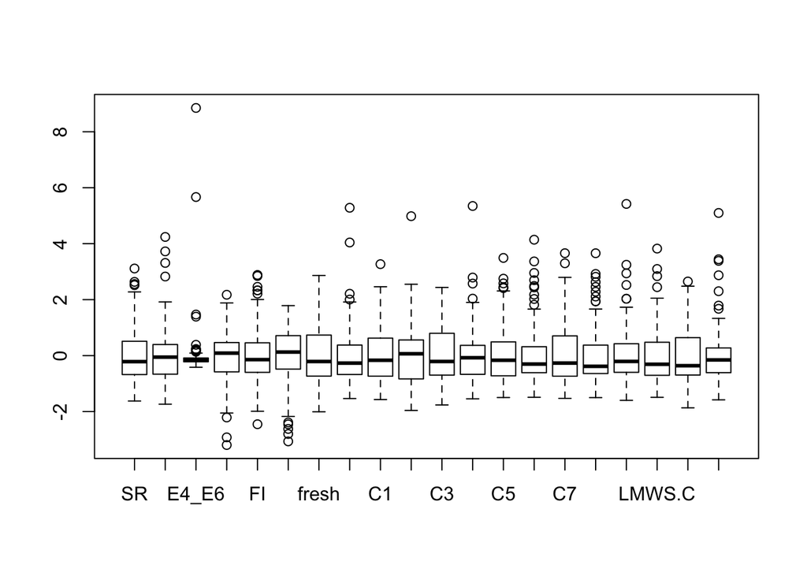

```r
boxplot(scale(DOM2))
```

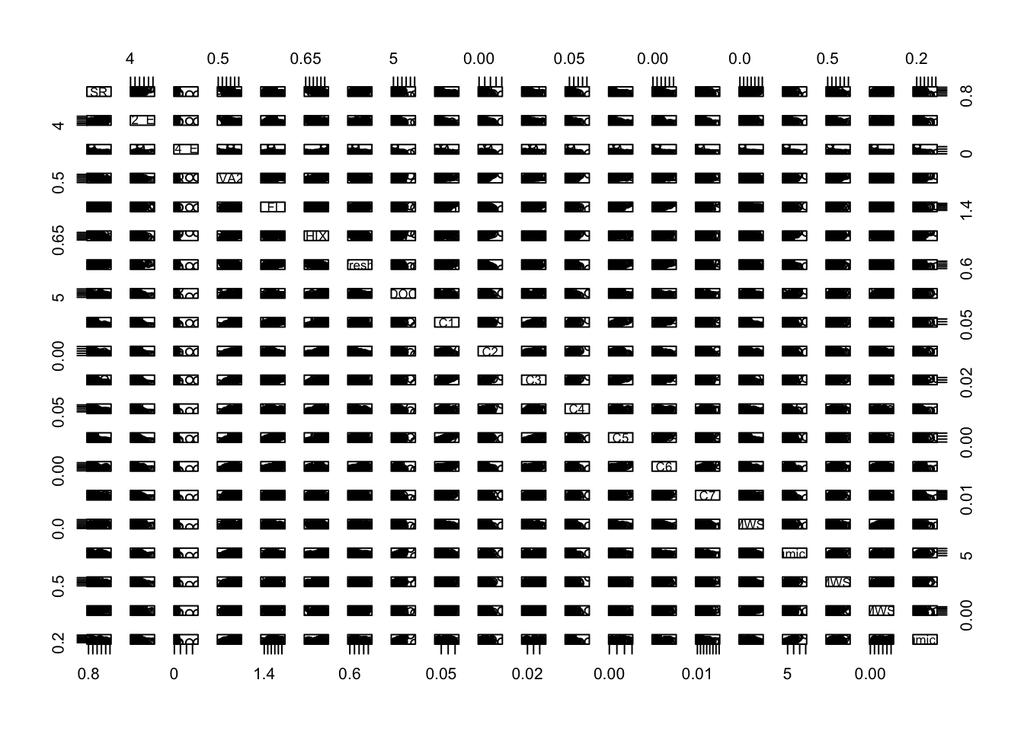

```r
# also make histograms
# maybe consider transformation of variables to improve linearity of relationships
plot(DOM2)
```

```r
# use quartz() or x11() to open a separate graphical device if you need it

# variable E4_E6 behaves differently than others (highly skewed)
any(DOM2$E4_E6<=0)
```

```
## [1] FALSE
```

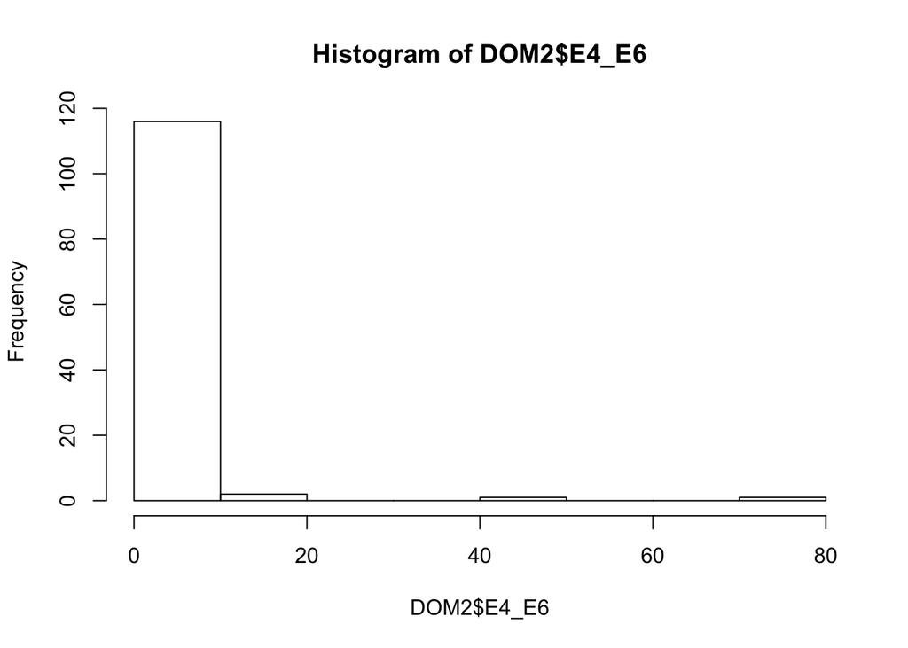

```r
hist(DOM2$E4_E6)
```

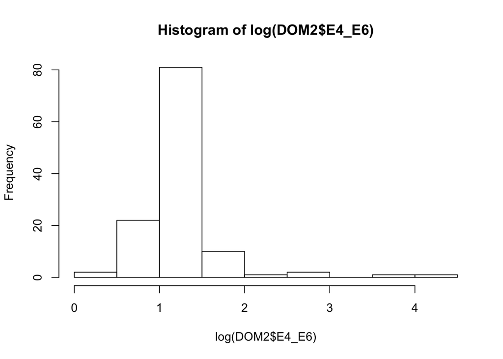

```r
hist(log(DOM2$E4_E6))
```

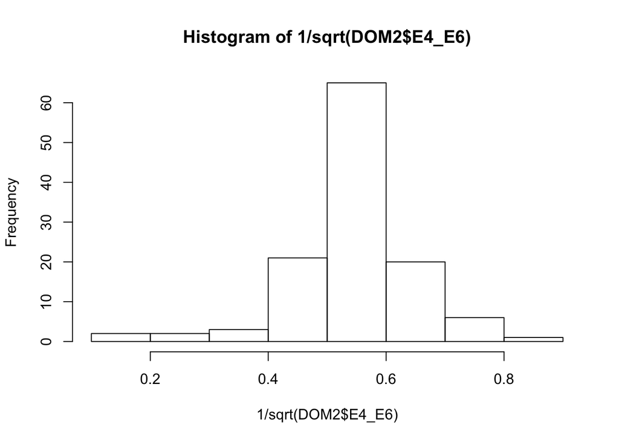

```r
hist(1/sqrt(DOM2$E4_E6)) # better (even if pretty arbitrary)
```

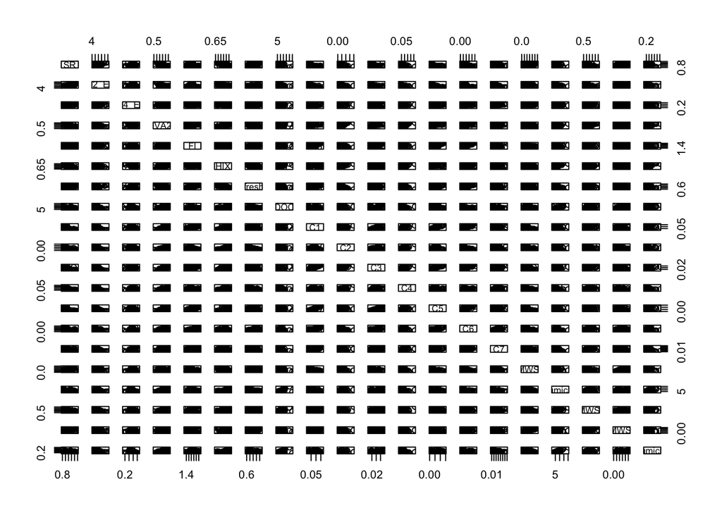

```r
DOM2$E4_E6<-1/sqrt(DOM2$E4_E6)
plot(DOM2)
```

```r
# run PCA
pca<-prcomp(DOM2,retx=TRUE,center=TRUE,scale.=TRUE)

summary(pca)
```

```
## Importance of components:
##                          PC1    PC2    PC3    PC4     PC5     PC6     PC7
## Standard deviation     2.665 1.9864 1.8234 1.4649 0.92995 0.82650 0.73085
## Proportion of Variance 0.355 0.1973 0.1663 0.1073 0.04324 0.03416 0.02671
## Cumulative Proportion  0.355 0.5524 0.7186 0.8259 0.86913 0.90329 0.92999
##                            PC8     PC9    PC10    PC11    PC12    PC13    PC14
## Standard deviation     0.56843 0.52760 0.45150 0.38926 0.30595 0.29026 0.28231
## Proportion of Variance 0.01616 0.01392 0.01019 0.00758 0.00468 0.00421 0.00399
## Cumulative Proportion  0.94615 0.96007 0.97026 0.97784 0.98252 0.98673 0.99071
##                           PC15    PC16    PC17    PC18    PC19    PC20
## Standard deviation     0.24453 0.21301 0.19173 0.15741 0.10307 0.09159
## Proportion of Variance 0.00299 0.00227 0.00184 0.00124 0.00053 0.00042
## Cumulative Proportion  0.99370 0.99597 0.99781 0.99905 0.99958 1.00000
```

```r
pca$sdev^2
```

```
##  [1] 7.101098206 3.945852418 3.324967581 2.145915191 0.864800478 0.683102155
##  [7] 0.534140175 0.323116468 0.278364075 0.203849225 0.151525032 0.093604740
## [13] 0.084248322 0.079700162 0.059794021 0.045372698 0.036759966 0.024777563
## [19] 0.010622889 0.008388634
```

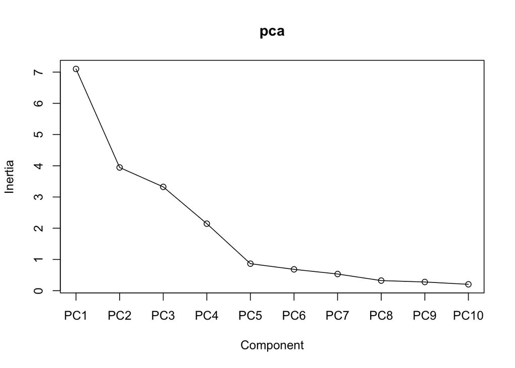

```r
screeplot(pca,type="lines")
```

```r
# We keep 2 axes of the PCA for graphing and further analysis. Alternatively we could keep 4, which is supported by the Scree plot as well and also by the eigenvalues (these drop below 1 at PC5)
```

2. Create a biplot for PC1 and PC2 with the most important variables defining these two axes. Plot the various water bodies and code symbol shape and symbol color to represent the study design targetting 4 water body types and 4 seasons. Note that sites and variables (or subsets thereof) do not have to be plotted onto a single biplot.

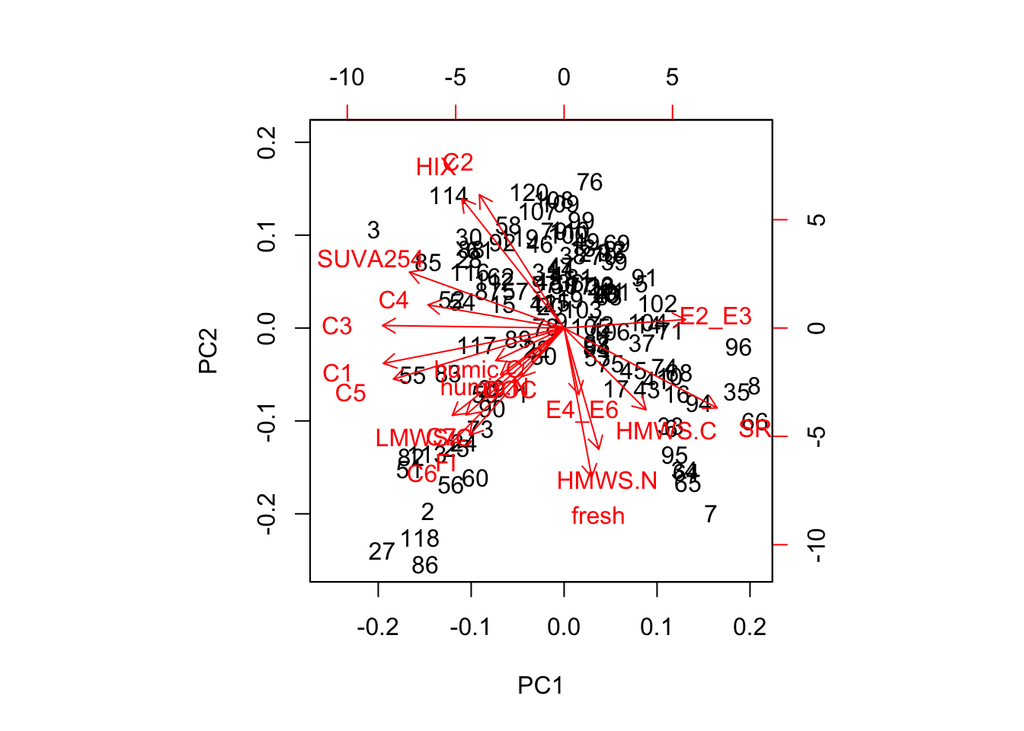

```r
# correlation biplot
biplot(pca) # quick and dirty
```

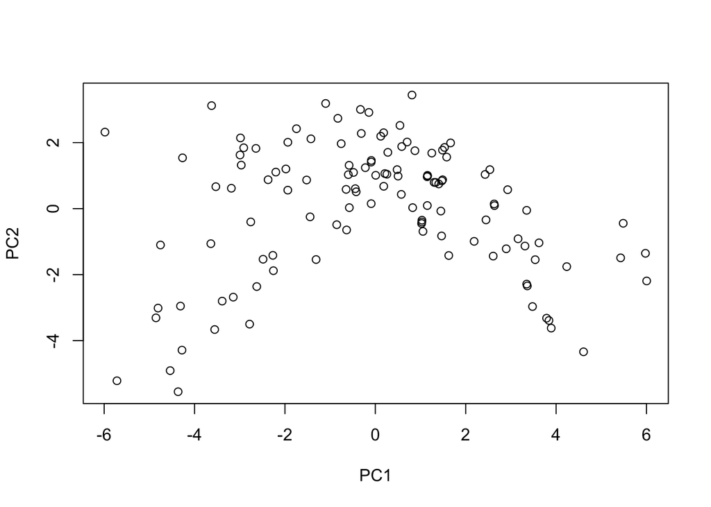

```r
# by hand:
plot(pca$x)
```

```r
# use different colors for water body types
levels(DOM$Type)
```

```
## [1] "lake"   "pond"   "river"  "stream"
```

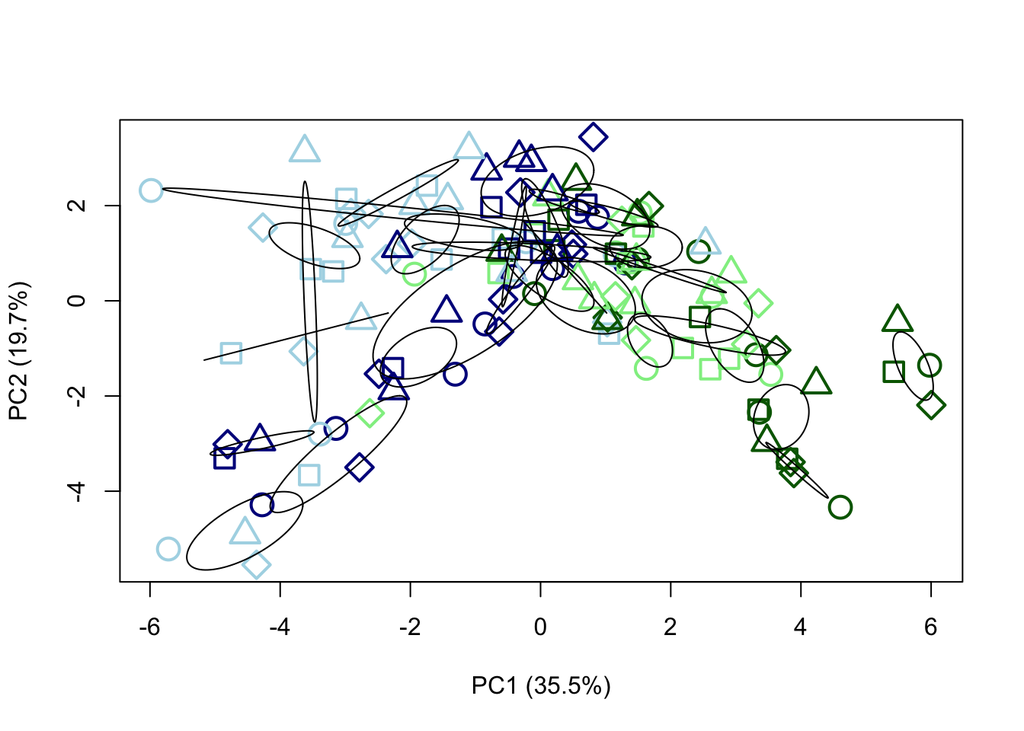

```r
DOM$col.type<-DOM$Type
levels(DOM$col.type)<-c("darkgreen","lightgreen","darkblue","lightblue")
DOM$col.type<-as.character(DOM$col.type)

# could use different symbols for season
DOM$pch.season<-DOM$Season
levels(DOM$pch.season)<-c(21:24)
DOM$pch.season<-as.numeric(as.character(DOM$pch.season))

# plot scores
plot(pca$x[,1],pca$x[,2],pch=DOM$pch.season,col=DOM$col.type,cex=2,lwd=2,
     xlab="PC1 (35.5%)", ylab="PC2 (19.7%)")
ordiellipse(pca,groups=DOM$Site)
```

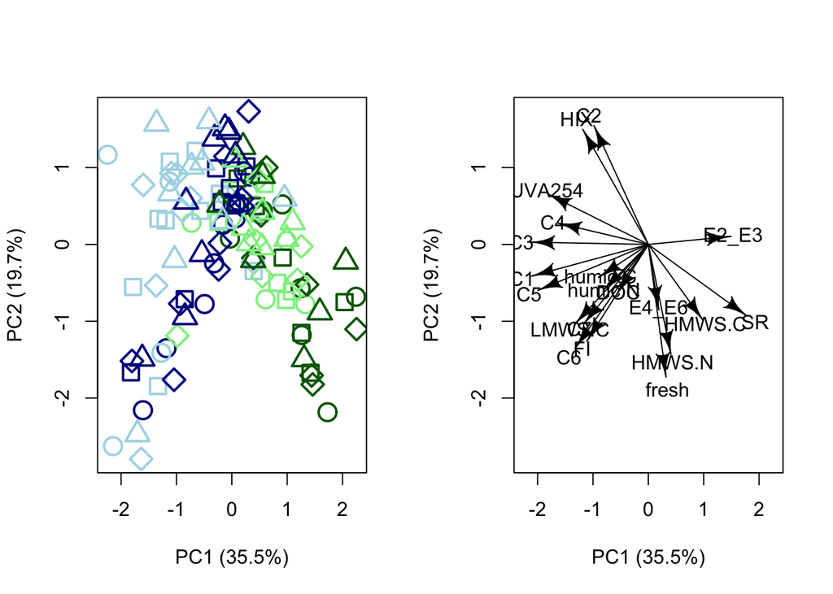

```r
# clean correlation biplot here
layout(matrix(1:2,1,2)) # make room for 2 plots
plot(pca$x[,1]/pca$sdev[1],pca$x[,2]/pca$sdev[2],pch=DOM$pch.season,col=DOM$col.type,cex=2,lwd=2,
     xlab="PC1 (35.5%)", ylab="PC2 (19.7%)")

plot(pca$x[,1]/pca$sdev[1],pca$x[,2]/pca$sdev[2],pch=DOM$pch.season,col="white",
     xlab="PC1 (35.5%)", ylab="PC2 (19.7%)")
structure<-cor(DOM2,pca$x)*2
Arrows(x0=0,y0=0,x1=structure[,1],y1=structure[,2])
text(structure[,1]*1.2,structure[,2]*1.2,names(DOM2))
```

3. Assess differences between water body types with respect to average composition of DOM and with respect to seasonal turnover of DOM composition. This question can be translated to an assessment of location and of seasonal variation along PC1 and PC2. You may add univariate formal hypothesis tests (Anova, t-test, Bartlett-test, F-test) using the PCs as response metavariables. Use various graphical means for plotting of the site scores for illustration. Which water bodies differ markedly among each other in DOM? Which water bodies show more seasonal DOM turnover?

```r
# run 2-way ANOVA assuming complete independence between all cases and seasons (120 different water bodies...)
m<-lm(pca$x[,1]~Season*Type,data=DOM)
anova(m)
```

```
## Analysis of Variance Table
##
## Response: pca$x[, 1]
##              Df Sum Sq Mean Sq F value Pr(>F)
## Season        3   1.37   0.456  0.1281 0.9432
## Type          3 464.22 154.740 43.5012 <2e-16 ***
## Season:Type   9   9.50   1.056  0.2968 0.9742
## Residuals   104 369.94   3.557
## ---
## Signif. codes:  0 '***' 0.001 '**' 0.01 '*' 0.05 '.' 0.1 ' ' 1
```

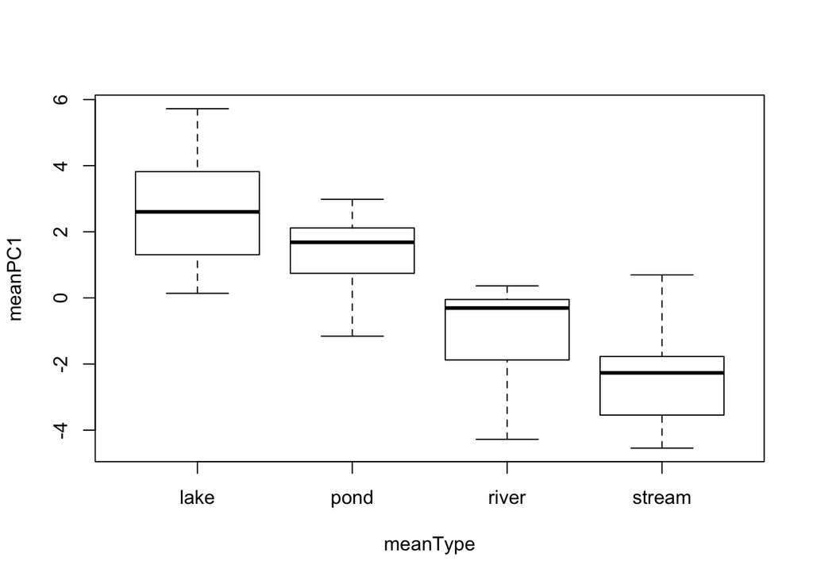

```r
# could do Bartlett-test, etc...
# a bit sloppy because it ignores repeated measures for each site, thus wrong d.f.
# could include "site" as random factor in a mixed model (but we don´t know how this works)
# or compute average per site over 4 seasons, information loss, but correct test

meanPC1<-tapply(pca$x[,1],DOM$Site,mean) # site-specific average location on PC1
varPC1<-tapply(pca$x[,1],DOM$Site,var) # site-specific seasonal variance on PC1
meanType<-DOM$Type[match(names(meanPC1),DOM$Site)]

boxplot(meanPC1~meanType)
```

```r
m2<-lm(meanPC1~meanType)
anova(m2)
```

```
## Analysis of Variance Table
##
## Response: meanPC1
##           Df  Sum Sq Mean Sq F value    Pr(>F)
## meanType   3 126.164  42.055  15.595 3.717e-06 ***
## Residuals 28  75.506   2.697
## ---
## Signif. codes:  0 '***' 0.001 '**' 0.01 '*' 0.05 '.' 0.1 ' ' 1
```

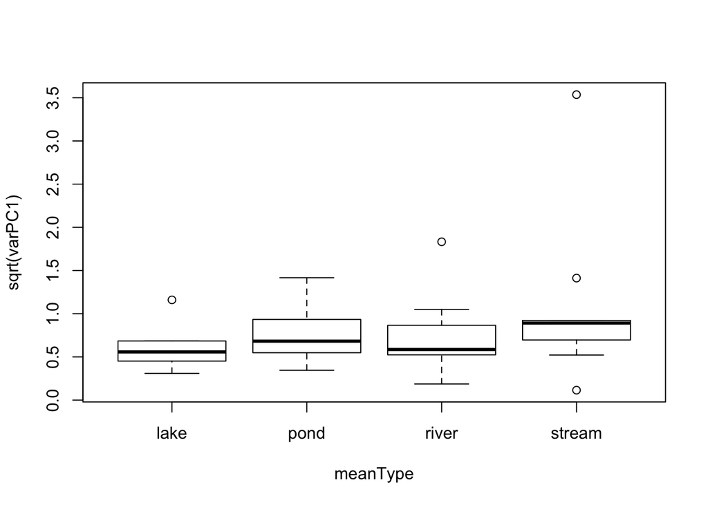

```r
# there is a significant effect of water body type on mean location along PC1

boxplot(sqrt(varPC1)~meanType)
```

```r
m3<-lm(sqrt(varPC1)~meanType)
anova(m3)
```

```
## Analysis of Variance Table
##
## Response: sqrt(varPC1)
##           Df  Sum Sq Mean Sq F value Pr(>F)
## meanType   3  0.9922 0.33072  0.8539 0.4764
## Residuals 28 10.8449 0.38732
```

```r
# there is NO significant effect of water body type on seasonal variance along PC1
```

4. Adding incomplete descriptors: Mass-spectrometric information is incomplete (we lack data from one season). It could still be informative to show how these data behave in the ordination space. Compute correlations with PCs and plot these as (maybe differently colored) arrows into ordination space.

```r
# adding mass-spectrometry information
# first just rebuild plot from above
plot(pca$x[,1]/pca$sdev[1],pca$x[,2]/pca$sdev[2],pch=DOM$pch.season,col="white",
     xlab="PC1 (35.5%)", ylab="PC2 (19.7%)")
Arrows(x0=0,y0=0,x1=structure[,1],y1=structure[,2]); text(structure[,1]*1.2,structure[,2]*1.2,names(DOM2))

# then add mass-spectrometry information
names(DOM)
```

```
##  [1] "sampleID"   "Season"     "Site"       "Date"       "Type"
##  [6] "latitude"   "longitude"  "SR"         "E2_E3"      "E4_E6"
## [11] "SUVA254"    "FI"         "HIX"        "fresh"      "DOC"
## [16] "C1"         "C2"         "C3"         "C4"         "C5"
## [21] "C6"         "C7"         "HMWS.C"     "humic.C"    "LMWS.C"
## [26] "HMWS.N"     "humic.N"    "avgmolmass" "molrich"    "DBE"
## [31] "AI"         "MLB"        "H_C"        "O_C"        "NH4"
## [36] "NO3"        "TP"         "Chla"       "AGR"        "FOR"
## [41] "PAV"        "URG"        "col.type"   "pch.season"
```

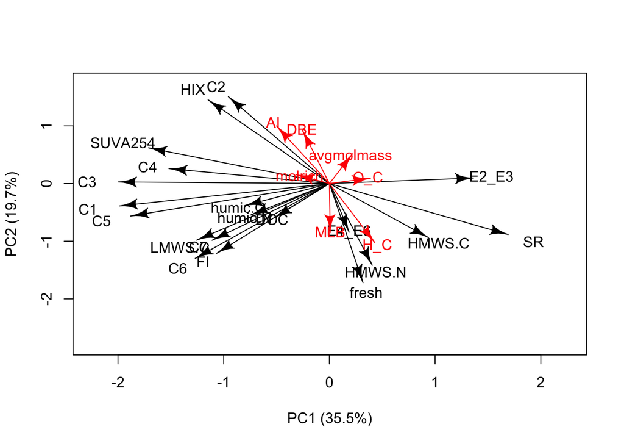

```r
DOM3<-DOM[,28:34]
structure2<-cor(DOM3,pca$x,use="complete.obs")*2
Arrows(x0=0,y0=0,x1=structure2[,1],y1=structure2[,2],col="red")
text(structure2[,1]*1.2,structure2[,2]*1.2,names(DOM3),col="red")
```

5. Assess potential drivers: The dataset includes a few variables that could be considered drivers of DOM composition (or drivers of processes that influence DOM). Assess these drivers by plotting them into ordination space and running correlations/regressions with PC1 and PC2.

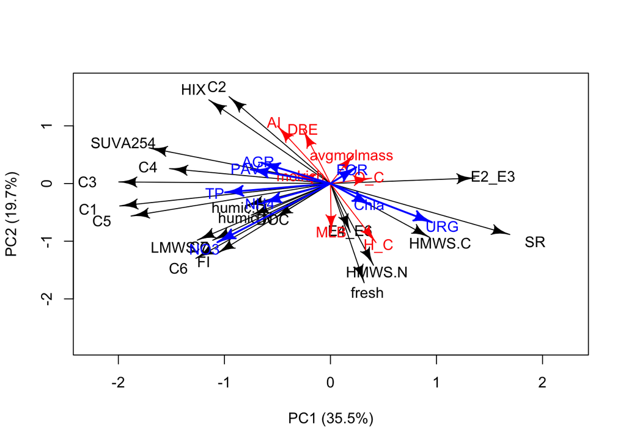

```r
# first just rebuild plot from above
plot(pca$x[,1]/pca$sdev[1],pca$x[,2]/pca$sdev[2],pch=DOM$pch.season,col="white",
     xlab="PC1 (35.5%)", ylab="PC2 (19.7%)")
Arrows(x0=0,y0=0,x1=structure[,1],y1=structure[,2]); text(structure[,1]*1.2,structure[,2]*1.2,names(DOM2))
Arrows(x0=0,y0=0,x1=structure2[,1],y1=structure2[,2],col="red")
text(structure2[,1]*1.2,structure2[,2]*1.2,names(DOM3),col="red")

# then add drivers
DOM4<-DOM[,35:42]
structure3<-cor(DOM4,pca$x,use="complete.obs")*2
Arrows(x0=0,y0=0,x1=structure3[,1],y1=structure3[,2],col="blue",lwd=2)
text(structure3[,1]*1.2,structure3[,2]*1.2,names(DOM4),col="blue")
```

```r
envfit() # take care: behaviour of variables not necessarily monotonous in ordination space
ordisurf() # as contourplot
```

6. **Bonus** Assessing drivers of DOM composition by post-hoc analysis of an unconstrained ordination like a PCA may not work well if those drivers exert only weak control or if important drivers were missed. Then the (variance-driven) PCA-dimensions may not be well aligned with the available drivers. RDA looks explicitly for an ordination that can be well aligned with a matrix of constraining variables. Run a RDA and compare its outcomes to PCA. As drivers of DOM composition you can consider nutrient concentrations, Chlorophyll-a, landuse percentages (NH4:URG). What do you learn when PCA and RDA result in either similar or different ordinations?

```r
# consider regressions to explain DOM quality
m1<-lm(pca$x[,1]~., data=DOM4)
summary(m1)
```

```
##
## Call:
## lm(formula = pca$x[, 1] ~ ., data = DOM4)
##
## Residuals:
##     Min      1Q  Median      3Q     Max
## -5.0683 -0.8223 -0.1485  1.0111  5.4935
##
## Coefficients:
##               Estimate Std. Error t value Pr(>|t|)
## (Intercept) -15.613817   8.286083  -1.884   0.0621 .
## NH4          -1.629921   0.325892  -5.001 2.15e-06 ***
## NO3          -0.667117   0.131353  -5.079 1.55e-06 ***
## TP           -0.004060   0.000945  -4.296 3.74e-05 ***
## Chla          0.019357   0.016969   1.141   0.2564
## AGR           0.135329   0.082955   1.631   0.1057
## FOR           0.175458   0.082824   2.118   0.0364 *
## PAV           0.155082   0.083296   1.862   0.0653 .
## URG           0.192053   0.083165   2.309   0.0228 *
## ---
## Signif. codes:  0 '***' 0.001 '**' 0.01 '*' 0.05 '.' 0.1 ' ' 1
##
## Residual standard error: 1.62 on 111 degrees of freedom
## Multiple R-squared:  0.6553, Adjusted R-squared:  0.6304
## F-statistic: 26.38 on 8 and 111 DF,  p-value: < 2.2e-16
```

```r
# do this much better with a RDA
zDOM2<-scale(DOM2) # must at least be centered even if dimensionally homogeneous!
xmat<-DOM4 # the constraints (or drivers or predictors)
myrda<-rda(zDOM2~.,data=xmat) # take care: confusing X and Y argument names if you work without formula notation

anova(myrda)
```

```
## Permutation test for rda under reduced model
## Permutation: free
## Number of permutations: 999
##
## Model: rda(formula = zDOM2 ~ NH4 + NO3 + TP + Chla + AGR + FOR + PAV + URG, data = xmat)
##           Df Variance     F Pr(>F)
## Model      8   8.7676 10.83  0.001 ***
## Residual 111  11.2324
## ---
## Signif. codes:  0 '***' 0.001 '**' 0.01 '*' 0.05 '.' 0.1 ' ' 1
```

```r
anova(myrda,by="axis",model="direct",perm.max=9999,step=1000)
```

```
## Permutation test for rda under direct model
## Forward tests for axes
## Permutation: free
## Number of permutations: 999
##
## Model: rda(formula = zDOM2 ~ NH4 + NO3 + TP + Chla + AGR + FOR + PAV + URG, data = xmat)
##           Df Variance       F Pr(>F)
## RDA1       1   4.7488 46.9282  0.001 ***
## RDA2       1   2.0316 20.0763  0.001 ***
## RDA3       1   1.2347 12.2014  0.001 ***
## RDA4       1   0.6040  5.9687  0.019 *
## RDA5       1   0.0778  0.7693  0.997
## RDA6       1   0.0438  0.4326  0.999
## RDA7       1   0.0219  0.2163  0.999
## RDA8       1   0.0050  0.0494  1.000
## Residual 111  11.2324
## ---
## Signif. codes:  0 '***' 0.001 '**' 0.01 '*' 0.05 '.' 0.1 ' ' 1
```

```r
anova(myrda,by="term",model="direct",perm.max=9999,step=1000)
```

```
## Permutation test for rda under direct model
## Terms added sequentially (first to last)
## Permutation: free
## Number of permutations: 999
##
## Model: rda(formula = zDOM2 ~ NH4 + NO3 + TP + Chla + AGR + FOR + PAV + URG, data = xmat)
##           Df Variance       F Pr(>F)
## NH4        1   0.9565  9.4525  0.001 ***
## NO3        1   2.9849 29.4971  0.001 ***
## TP         1   1.1707 11.5692  0.001 ***
## Chla       1   0.7192  7.1077  0.001 ***
## AGR        1   0.9566  9.4534  0.001 ***
## FOR        1   0.2826  2.7924  0.025 *
## PAV        1   1.5382 15.2009  0.001 ***
## URG        1   0.1588  1.5693  0.166
## Residual 111  11.2324
## ---
## Signif. codes:  0 '***' 0.001 '**' 0.01 '*' 0.05 '.' 0.1 ' ' 1
```

```r
anova(myrda,by="margin",model="direct",perm.max=9999,step=1000)
```

```
## Permutation test for rda under direct model
## Marginal effects of terms
## Permutation: free
## Number of permutations: 999
##
## Model: rda(formula = zDOM2 ~ NH4 + NO3 + TP + Chla + AGR + FOR + PAV + URG, data = xmat)
##           Df Variance       F Pr(>F)
## NH4        1   0.9980  9.8622  0.001 ***
## NO3        1   1.9769 19.5364  0.001 ***
## TP         1   0.7576  7.4870  0.001 ***
## Chla       1   0.4187  4.1374  0.006 **
## AGR        1   0.1327  1.3114  0.221
## FOR        1   0.1491  1.4736  0.167
## PAV        1   0.1254  1.2394  0.250
## URG        1   0.1588  1.5693  0.138
## Residual 111  11.2324
## ---
## Signif. codes:  0 '***' 0.001 '**' 0.01 '*' 0.05 '.' 0.1 ' ' 1
```

```r
(sites<-scores(myrda,choices=c(1,2),display="sites",scaling=1))
```

[output not shown]

[output cut: 68 more lines]

```
## row108 -0.013132656 -0.2719533855
## row109  0.009933244 -0.2712321996
## row110  0.070008500 -0.2791419332
## row111  0.043140617 -0.0154216953
## row112 -0.301063295 -0.0411364759
## row113 -0.678522181  0.3486793001
## row114 -0.440941273 -0.6451392805
## row115 -0.036022516  0.0632147756
## row116 -0.380972191 -0.5401306483
## row117 -0.372107932 -0.3825648298
## row118 -0.743464355  0.6260036928
## row119 -0.146079910 -0.1754999589
## row120 -0.108450127 -0.2408563948
## attr(,"const")
## [1] 6.984643
```

```r
(lcs<-scores(myrda,choices=c(1,2),display="lc",scaling=1))
```

[output not shown]

[output cut: 68 more lines]

```
## row108  0.0536056743 -0.0331871954
## row109 -0.0306540535 -0.0846406901
## row110  0.2641441420 -0.0880192718
## row111  0.1224116951  0.0966288061
## row112 -0.0256153526 -0.0874992379
## row113  0.1193988570 -0.0345543673
## row114 -0.0264574547 -0.0880465970
## row115  0.0855834315  0.0394050226
## row116 -0.0127579994 -0.3899281507
## row117 -0.2964229164 -0.5630798348
## row118 -0.8062419467  0.1307508174
## row119 -0.0939394092 -0.3111722516
## row120 -0.0221754508 -0.0803283019
## attr(,"const")
## [1] 6.984643
```

```r
(species<-scores(myrda,choices=c(1,2),display="species",scaling=1)*0.2)
```

```
##                RDA1         RDA2
## SR       0.40601842  0.290245071
## E2_E3    0.33040652  0.007788518
## E4_E6    0.04707924  0.244679727
## SUVA254 -0.37017278 -0.249183935
## FI      -0.37848060  0.438793112
## HIX     -0.21395766 -0.470175069
## fresh   -0.01650735  0.622606531
## DOC     -0.18102761 -0.250326885
## C1      -0.51426156  0.091438479
## C2      -0.12255328 -0.509093605
## C3      -0.47849558 -0.086414083
## C4      -0.33872485 -0.058581339
## C5      -0.49971704  0.163436024
## C6      -0.38066550  0.516488556
## C7      -0.30008080  0.355690356
## HMWS.C   0.20925275  0.083126553
## humic.C -0.17233105 -0.277407920
## LMWS.C  -0.32327823  0.014278670
## HMWS.N   0.07805701  0.177942015
## humic.N -0.15537695 -0.259004591
## attr(,"const")
## [1] 6.984643
```

```r
(constraints<-scores(myrda,choices=c(1,2),display="bp",scaling=1)*3)
```

```
##            RDA1        RDA2
## NH4  -0.5074611  0.12371914
## NO3  -0.9834948  0.50831073
## TP   -0.8001725 -0.26560291
## Chla  0.2701233 -0.02171975
## AGR  -0.4527730 -0.52115123
## FOR   0.1668652 -0.20078988
## PAV  -0.5905096  0.07748153
## URG   0.7333030  0.42157274
## attr(,"const")
## [1] 6.984643
```

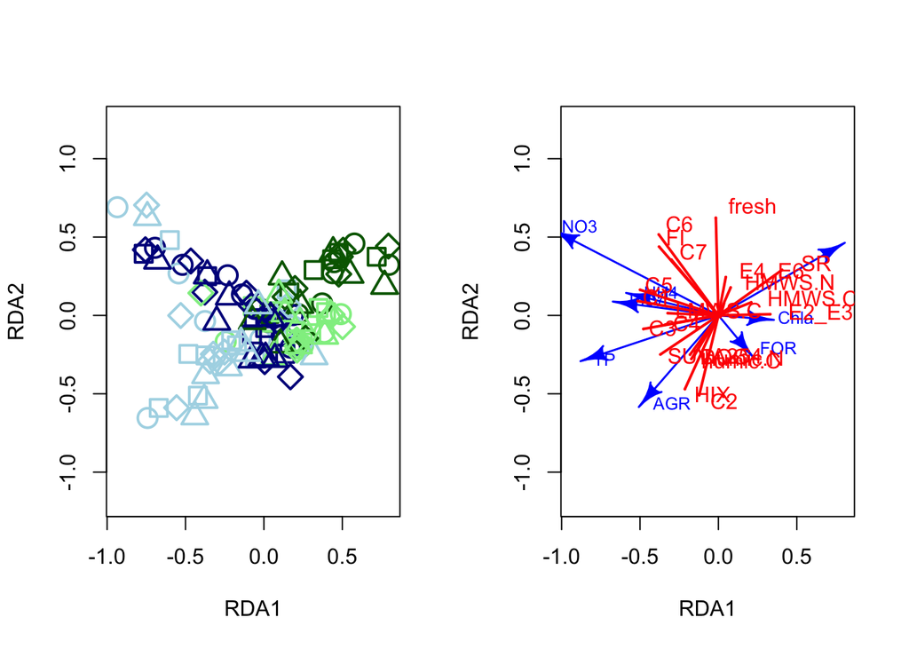

```r
layout(matrix(1:2,1,2)) # make room for 2 plots
plot(sites,asp=1,pch=DOM$pch.season,col=DOM$col.type,cex=2,lwd=2)
#plot(lcs,asp=1,pch=DOM$pch.season,col=DOM$col.type,cex=2,lwd=2)

plot(sites,asp=1,pch=DOM$pch.season,col="white",cex=2,lwd=2)
Arrows(x0=0,y0=0,x1=constraints[,1],y1=constraints[,2],lwd=1.5,col="blue")
text(constraints[,1]*1.1,constraints[,2]*1.1,label=rownames(constraints),pos=4,cex=0.8,col="blue")

Arrows(x0=0,y0=0,x1=species[,1],y1=species[,2],lwd=2,arr.length=0,col="red")
text(species[,1:2]*1.1,label=rownames(species),pos=4,cex=1,col="red")
```